# Genomic data manipulation in R

Authors

Affiliations

dr.sc. Paula Štancl

Bioinformatics group

dr.sc. Filip Horvat

Max Perutz Labs, Vienna Biocenter Campus (VBC), Vienna, Austria

## What is **Bioconductor**?

### Bioinformatics has always benefited from curated packages and repositories.

There is no need to reinvent the wheel!

[figure not shown]

### In **R**, we have **Bioconductor**

[figure not shown]

Bioconductor provides tools for the analysis and comprehension of high-throughput genomic data.

**The broad goals of the Bioconductor project are:**

- To provide a **common software platform** that enables the rapid development and deployment of **extensible, scalable, and interoperable** software.
- To provide widespread access to a broad range of powerful **statistical and graphical methods** for the analysis of genomic data.
- To facilitate the **inclusion of biological metadata** in the analysis of genomic data, e.g. literature data from PubMed, annotation data from Entrez genes.
- To further scientific understanding by producing **high-quality documentation** and reproducible research.
- To **train researchers** on computational and statistical methods for the analysis of genomic data.

### How does it look like

[https://www.bioconductor.org/]

[figure not shown]

## What is **Biostrings**?

```r
if (!requireNamespace("BiocManager", quietly = TRUE))
    install.packages("BiocManager")

if (!requireNamespace("Biostrings", quietly = TRUE))
    BiocManager::install("Biostrings")
if (!requireNamespace("pwalign", quietly = TRUE))
    BiocManager::install("pwalign")

library(Biostrings)
library(pwalign)
```

Efficient manipulation of biological strings:

- DNA / RNA / AA Sequences
- Alignments

### Sequences

Sequences are treated as objects which can be made of individual entries

```r
stSingle <- DNAString("ACTGCTAGCTAGATTAGGCTCCTATCAGA")
stSingle
```

```
29-letter DNAString object
seq: ACTGCTAGCTAGATTAGGCTCCTATCAGA
```

or multiple, which are called sets:

```r
stSet <- DNAStringSet(c("ACTGCTAGCTAGATTAGGCTCCTATCAGA", "CTAGCTAGATTAGGCTCCTCATCAGAATCGAGTAACA"))
stSet
```

```
DNAStringSet object of length 2:
    width seq
[1]    29 ACTGCTAGCTAGATTAGGCTCCTATCAGA
[2]    37 CTAGCTAGATTAGGCTCCTCATCAGAATCGAGTAACA
```

### Alignments

Pairwise alignments (local and global) are made with the **pwalign** package (this function used to be part of **Biostrings**)

pairwiseAlignment

```r
stSingle1 <- DNAString("ACTGCTAGCTAGATTAGGCTCCTAGCATCTAGA")
stSingle2 <- DNAString("CTAGGCTAGATTAGGCTCCTAGCATCAGACGATCGAGTAACA")
```

```r
pwalign::pairwiseAlignment(stSingle1, stSingle2, type = "local")
```

```
Local PairwiseAlignmentsSingleSubject (1 of 1)
pattern: [8] GCTAGATTAGGCTCCTAGCATC
subject: [5] GCTAGATTAGGCTCCTAGCATC
score: 43.59863
```

and while it can not do multiple alignments, it can read them:

- `readDNAMultipleAlignment()`
- `readRNAMultipleAlignment()`
- `readAAMultipleAlignment()`

## **Reading Data**

Fasta files are read with functions:

- `readBStringSet()`
- `readDNAStringSet()`
- `readRNAStringSet()`
- `readAAStringSet()`

```r
cds <- readDNAStringSet("data/Caenorhabditis_elegans.WBcel235.cds.first_20.fa.gz")
cds
```

```
DNAStringSet object of length 20:
     width seq                                              names
 [1]  1569 ATGAGCACAACACCTGGAACTCC...TCCTAAATCCATCCCGGAATAG Y110A7A.10.1 cds ...
 [2]  1482 ATGACAGCTGAAAAGGAGCCGTT...CGACGAGGATAAGGAGGATTAG F27C8.1.1 cds chr...
 [3]  1452 ATGAACGAAAAAGAAGAAGAAGT...CCCAGAACTCTCCAGTTCCTGA F07C3.7.1 cds chr...
 [4]  1482 ATGGGTAAGCAAGAACAATCGGA...CGACGCCAACAAAGAGGAATAG F52H2.2a.1 cds ch...
 [5]  1590 ATGTCTGCCCATTCCTCGTCATT...CGACGCCAACAAAGAGGAATAG F52H2.2b.1 cds ch...
 ...   ... ...
[16]   270 ATGAATTTCAGTTTTTTATTTTT...CGGCAATAATGGTCTCCAGTAA F54B8.5.1 cds chr...
[17]   372 ATGATTTGCAACTGCTTTCTTCT...ATGGCAACGTGGATGGCAGTGA Y38H6C.22.1 cds c...
[18]   390 ATGAACTATAACTTTTTGCTGCT...ATACGACACTGATCGGAACTGA T22H6.5.1 cds chr...
[19]   588 ATGTTTAGAAAATTAATCATTGC...GAATTTGAAGAAAAAACGTTAA T22H6.7.1 cds chr...
[20]  3675 ATGGGTCATTCACATAGTACTGG...CATGAGGCTGGTGGATCGCTGA M79.1a.1 cds chro...
```

Or proteins:

```r
pep <- readAAStringSet("data/Caenorhabditis_elegans.WBcel235.pep.first_20.fa.gz")
pep
```

```
AAStringSet object of length 20:
     width seq                                              names
 [1]   522 MSTTPGTPHGVTHSLMEQGWYWA...DTPSSSDSRLVHPTTLPKSIPE Y110A7A.10.1 pep ...
 [2]   493 MTAEKEPLKSREGDEAPQNETEG...FIDSSTVFIQKLFMVVDEDKED F27C8.1.1 pep chr...
 [3]   483 MNEKEEEVSLNQIKLKPRISLFN...VWIGFTHFIQKLFYCVPELSSS F07C3.7.1 pep chr...
 [4]   493 MGKQEQSEPLNQEPSNEHHDEEV...LTDSVTIFTQKLFMVVDANKEE F52H2.2a.1 pep ch...
 [5]   529 MSAHSSSFALCPSNGRHTHTHTH...LTDSVTIFTQKLFMVVDANKEE F52H2.2b.1 pep ch...
 ...   ... ...
[16]    89 MNFSFLFFIFAFLIGLNKGSVCL...VCEKCYRDSYGNAIYPGNNGLQ F54B8.5.1 pep chr...
[17]   123 MICNCFLLIIVTLVISNCDGICL...RQYNRQLRQQNRMNKAWQRGWQ Y38H6C.22.1 pep c...
[18]   129 MNYNFLLLSACIIFLIPEKSESI...TMNQRNEDDLYPSQDRYDTDRN T22H6.5.1 pep chr...
[19]   195 MFRKLIIATFVLSLCDLANSVTI...GNAGQAGQTGYPSGYQNLKKKR T22H6.7.1 pep chr...
[20]  1224 MGHSHSTGKEINDNELFTCEDPV...VDDKLKMAFQDCFDQIMRLVDR M79.1a.1 pep chro...
```

## **Manipulating a String Set**

**Biostrings** objects respond to typical R syntax for their manipulation.

```r
pep[width(pep) >= 530]
```

```
AAStringSet object of length 3:
    width seq                                               names
[1]   537 MDESHKMGFLGATSYVIGNIIGS...AAGLKMLISSVPSSLVDLISDVQ C55C2.5a.1 pep ch...
[2]   541 MSSIEDLPTVGDVAATRHQMGLW...RTTLSTSQIDTAAAGTAEPMTRL Y53H1C.1a.1 pep c...
[3]  1224 MGHSHSTGKEINDNELFTCEDPV...PVDDKLKMAFQDCFDQIMRLVDR M79.1a.1 pep chro...
```

In some cases, functions have the same name as in base R but when applied to a **Biostrings** object you will get the **Biostrings** functionality:

For example:

```r
length(pep)
```

```
[1] 20
```

```r
head(pep)
```

```
AAStringSet object of length 6:
    width seq                                               names
[1]   522 MSTTPGTPHGVTHSLMEQGWYWA...PDTPSSSDSRLVHPTTLPKSIPE Y110A7A.10.1 pep ...
[2]   493 MTAEKEPLKSREGDEAPQNETEG...EFIDSSTVFIQKLFMVVDEDKED F27C8.1.1 pep chr...
[3]   483 MNEKEEEVSLNQIKLKPRISLFN...SVWIGFTHFIQKLFYCVPELSSS F07C3.7.1 pep chr...
[4]   493 MGKQEQSEPLNQEPSNEHHDEEV...SLTDSVTIFTQKLFMVVDANKEE F52H2.2a.1 pep ch...
[5]   529 MSAHSSSFALCPSNGRHTHTHTH...SLTDSVTIFTQKLFMVVDANKEE F52H2.2b.1 pep ch...
[6]   526 MGSIEGVPTIGDIAASRHQMGLW...YEAVASQDDRTKLPTTHVDETGF T13A10.10a.1 pep ...
```

```r
width(pep) # analogous to nchar()
```

```
 [1]  522  493  483  493  529  526  537  523  513  500  483  541  527   85   85
[16]   89  123  129  195 1224
```

## **Counting Patterns/Characters**

Lets recycle this sequence

```r
stSingle <- DNAString("ACTGCTAGCTAGATTAGGCTCCTAGCATCAGA")
```

Instead of `grep()`, **Biostrings** allows to match or count substrings to a subject, for example

```r
countPattern("AGA", stSingle)
```

```
[1] 2
```

```r
matchPattern("AGA", stSingle)
```

```
Views on a 32-letter DNAString subject
subject: ACTGCTAGCTAGATTAGGCTCCTAGCATCAGA
views:
      start end width
  [1]    11  13     3 [AGA]
  [2]    30  32     3 [AGA]
```

We can also benefit of knowing that these are Biological sequences and use [IUPAC codes instead](https://www.bioinformatics.org/sms/iupac.html) For example:

```
R:  A or G
Y:  C or T
```

```r
countPattern("R", stSingle, fixed = F)
```

```
[1] 16
```

```r
matchPattern("R", stSingle, fixed = F)
```

```
Views on a 32-letter DNAString subject
subject: ACTGCTAGCTAGATTAGGCTCCTAGCATCAGA
views:
       start end width
   [1]     1   1     1 [A]
   [2]     4   4     1 [G]
   [3]     7   7     1 [A]
   [4]     8   8     1 [G]
   [5]    11  11     1 [A]
   ...   ... ...   ... ...
  [12]    25  25     1 [G]
  [13]    27  27     1 [A]
  [14]    30  30     1 [A]
  [15]    31  31     1 [G]
  [16]    32  32     1 [A]
```

```r
countPattern("Y", stSingle, fixed = F)
```

```
[1] 16
```

```r
matchPattern("Y", stSingle, fixed = F)
```

```
Views on a 32-letter DNAString subject
subject: ACTGCTAGCTAGATTAGGCTCCTAGCATCAGA
views:
       start end width
   [1]     2   2     1 [C]
   [2]     3   3     1 [T]
   [3]     5   5     1 [C]
   [4]     6   6     1 [T]
   [5]     9   9     1 [C]
   ...   ... ...   ... ...
  [12]    22  22     1 [C]
  [13]    23  23     1 [T]
  [14]    26  26     1 [C]
  [15]    28  28     1 [T]
  [16]    29  29     1 [C]
```

This function work only on `XXString` object and do not work on `XXStringSet` object. How can we count patterns in multiple sequences?

```r
vcountPattern("AACGA",
              stSet,
              max.mismatch=2,
              min.mismatch=1)
```

```
[1] 1 3
```

## **More functionality**

Transformations like translation or reverse are also available:

```r
translate(stSingle)
```

```
10-letter AAString object
seq: TAS*IRLLAS
```

```r
reverse(stSingle)
```

```
32-letter DNAString object
seq: AGACTACGATCCTCGGATTAGATCGATCGTCA
```

```r
reverseComplement(stSingle)
```

```
32-letter DNAString object
seq: TCTGATGCTAGGAGCCTAATCTAGCTAGCAGT
```

Subseting based on position:

```r
subseq(stSingle, start = 3, end = 7)
```

```
5-letter DNAString object
seq: TGCTA
```

Frequency of letters:

```r
alphabetFrequency(stSingle)
```

```
A C G T M R W S Y K V H D B N - + .
9 8 7 8 0 0 0 0 0 0 0 0 0 0 0 0 0 0
```

```r
alphabetFrequency(stSingle, baseOnly = TRUE, as.prob = TRUE)
```

```
      A       C       G       T   other
0.28125 0.25000 0.21875 0.25000 0.00000
```

Frequency of K-mers:

```r
oligonucleotideFrequency(stSingle, width = 3)
```

```
AAA AAC AAG AAT ACA ACC ACG ACT AGA AGC AGG AGT ATA ATC ATG ATT CAA CAC CAG CAT
  0   0   0   0   0   0   0   1   2   2   1   0   0   1   0   1   0   0   1   1
CCA CCC CCG CCT CGA CGC CGG CGT CTA CTC CTG CTT GAA GAC GAG GAT GCA GCC GCG GCT
  0   0   0   1   0   0   0   0   3   1   1   0   0   0   0   1   1   0   0   3
GGA GGC GGG GGT GTA GTC GTG GTT TAA TAC TAG TAT TCA TCC TCG TCT TGA TGC TGG TGT
  0   1   0   0   0   0   0   0   0   0   4   0   1   1   0   0   0   1   0   0
TTA TTC TTG TTT
  1   0   0   0
```

Converting to character vector:

```r
toString(stSingle)
```

```
[1] "ACTGCTAGCTAGATTAGGCTCCTAGCATCAGA"
```

##### Task

1. Create a function `genSeq` that will randomly generate a DNA sequence of length *n_len*.

```r
# randomly generate a sequence
```

2. Create a DNAStringSet object `dna` with two sequences names *seq1* and *seq2* of length 1010 and 5305.

```r
# set seed to 41
```

3. Calculate the GC content.
4. Select only the *first* sequence in a `seq1` variable .
5. Subset the *first* sequence so it start with the first `ATG`.

## What is **GenomicRanges**?

### Genomic locations within Bioconductor project

*GenomicRanges* package defines general purpose containers for storing and manipulating genomic intervals and variables defined along a genome

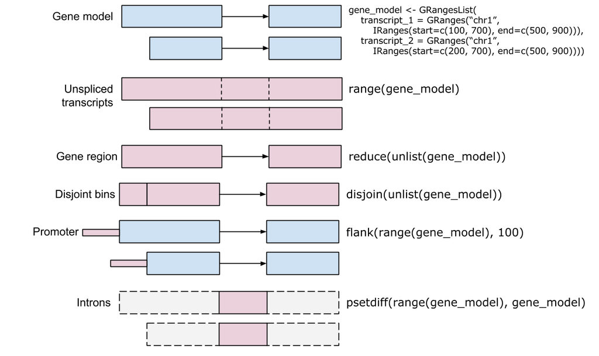

### Instalation and use

Install with:

```r
if (!requireNamespace("BiocManager", quietly = TRUE))
  install.packages("BiocManager")
BiocManager::install("GenomicRanges")
```

Libraries you’re gonna need for this lecture:

```r
library(data.table) # load before IRanges so that shift() is IRanges::shift
library(GenomicRanges)
library(IRanges)
# library(ggbio)
library(ggplot2)
library(magrittr)
```

## **IRanges** package

### Foundation of integer range manipulation in Bioconductor

#### IRanges object structure

IRanges object:

```r
(range_1 <- IRanges(start = 5, end = 11))
```

```
IRanges object with 1 range and 0 metadata columns:
          start       end     width
      <integer> <integer> <integer>
  [1]         5        11         7
```

Let’s look at the structure:

```r
str(range_1)
```

```
Formal class 'IRanges' [package "IRanges"] with 6 slots
  ..@ start          : int 5
  ..@ width          : int 7
  ..@ NAMES          : NULL
  ..@ elementType    : chr "ANY"
  ..@ elementMetadata: NULL
  ..@ metadata       : list()
```

**Tip**

We can access *start*, *end*, *width* and other slots using `@`, but this is not recommended.  
The best approach is to use in-built functions.

Let’s create another IRanges object:

```r
(range_2 <- IRanges(start = c(5, 7, 1),
                    width = c(6, 9, 3)))
```

```
IRanges object with 3 ranges and 0 metadata columns:
          start       end     width
      <integer> <integer> <integer>
  [1]         5        10         6
  [2]         7        15         9
  [3]         1         3         3
```

#### Basic slots

Accessing *start*, *end* and *width* is simple:

```r
start(range_2)
```

```
[1] 5 7 1
```

```r
end(range_2)
```

```
[1] 10 15  3
```

```r
width(range_2)
```

```
[1] 6 9 3
```

#### Some other basic methods

**Joining ranges:**

```r
c(range_1, range_2)
```

```
IRanges object with 4 ranges and 0 metadata columns:
          start       end     width
      <integer> <integer> <integer>
  [1]         5        11         7
  [2]         5        10         6
  [3]         7        15         9
  [4]         1         3         3
```

**Subset:**

```r
range_2[2:3]
```

```
IRanges object with 2 ranges and 0 metadata columns:
          start       end     width
      <integer> <integer> <integer>
  [1]         7        15         9
  [2]         1         3         3
```

```r
range_2[width(range_2) > 4]
```

```
IRanges object with 2 ranges and 0 metadata columns:
          start       end     width
      <integer> <integer> <integer>
  [1]         5        10         6
  [2]         7        15         9
```

**Important**

**Arithmetic operations** on `IRanges` do not mean adding to or subtracting from coordinates directly — instead, they **expand or contract the ranges symmetrically**.

- `range + k` expands each range by `k` bases on **both** sides.
- `range - k` contracts each range by `k` bases on **both** sides.

This means:

$$\text{new start} = \text{old start} - k$$

$$\text{new end} = \text{old end} + k$$

$$\text{new width} = \text{old width} + 2k$$

```r
range_2
```

```
IRanges object with 3 ranges and 0 metadata columns:
          start       end     width
      <integer> <integer> <integer>
  [1]         5        10         6
  [2]         7        15         9
  [3]         1         3         3
```

```r
range_2 + 1
```

```
IRanges object with 3 ranges and 0 metadata columns:
          start       end     width
      <integer> <integer> <integer>
  [1]         4        11         8
  [2]         6        16        11
  [3]         0         4         5
```

```r
range_2 - 1
```

```
IRanges object with 3 ranges and 0 metadata columns:
          start       end     width
      <integer> <integer> <integer>
  [1]         6         9         4
  [2]         8        14         7
  [3]         2         2         1
```

**Reverse ranges:**

The function `rev()` reverses the order of the ranges in the IRanges object — not their coordinates.

```r
rev(range_2)
```

```
IRanges object with 3 ranges and 0 metadata columns:
          start       end     width
      <integer> <integer> <integer>
  [1]         1         3         3
  [2]         7        15         9
  [3]         5        10         6
```

**Counting number of ranges over each position:**

The function `coverage()` counts, for every genomic position, **how many ranges overlap** that position.  
It returns an object of class `Rle` (Run-Length Encoding), which efficiently stores repeated values.

```r
coverage(range_2)
```

```
integer-Rle of length 15 with 5 runs
  Lengths: 3 1 2 4 5
  Values : 1 0 1 2 1
```

## **IRanges** methods overview

**Important**

**Set operations**

Set operations on *IRanges* object reflect traditional mathematical set operations *complement*, *union*, *intersect*, and *difference*. There are two variants for each operation:

- the first treats each *IRanges* object as a set and returns a normal value
- the other has a parallel semantic (like pmin/pmax) and performs the operation for each range pairing separately

```
(p)union() # union
(p)intersect() # intersect
(p)setdiff() # difference
(p)gaps() # complement
```

**Intra range methods**

Intra range methods transform each range individually and independently of other ranges. They return an object parallel to the input object - the *i-th* range corresponds to the *i-th* range in the input.

```
shift()
narrow()
resize()
flank()
promoters()
reflect()
restrict()
```

**Inter range methods**

Inter range methods transform all the ranges as a set to produce a new set of ranges. They return an object that is generally NOT parallel to the input object.

```
range()
reduce()
disjoin()
```

#### Exploring methods

In order to understand what is each of those functions doing, we will create a helper functions to visualize *IRanges*. We want to plot ranges and result of the method applied to those ranges - all on one plot. We will use *ggplot2* which accepts table as input. First we need to create a function which will join ranges and result of the method to one table. We need unique identifier for each range and result of the method so we can plot them in different colors. Something like this:

```
IRangesMethodToTable(method, range_1, range_2)
```

### Ranges-to-table function

Function takes ranges and method as input and returns ranges and result of the method in one table:

```r
IRangesMethodToTable <- function(IRangesMethod, ...){

  # apply method to IRanges
  irange_result <- IRangesMethod(...)

  # create list of IRanges
  irange_list <- list(..., irange_result)

  # loop through the list: transform to table, add unique id
  irange_tb <- lapply(seq_along(irange_list), function(index){

    if(class(irange_list[[index]]) %in% c("IRanges", "GRanges")){
      as.data.table(irange_list[[index]])[, range_id := index]
    }

  })

  # bind to one table (NULLs are skipped, missing columns filled with NA)
  irange_tb <- rbindlist(irange_tb, use.names = TRUE, fill = TRUE)

  # replace last added range with NA
  irange_tb[, range_id := fifelse(range_id == max(range_id),
                                  NA_character_,
                                  paste("range", range_id, sep = "."))]

  # return table
  return(irange_tb)

}
```

Test run:

```r
range_1 <- IRanges(start = c(4, 18, 1),
                   width = c(3, 4, 3))
range_2 <- IRanges(start = c(8, 3, 16),
                   width = c(5, 10, 4))
joined_ranges_tb <- IRangesMethodToTable(IRanges::union, range_1, range_2)

print(joined_ranges_tb)
```

```
   start   end width range_id
   <int> <int> <int>   <char>
1:     4     6     3  range.1
2:    18    21     4  range.1
3:     1     3     3  range.1
4:     8    12     5  range.2
5:     3    12    10  range.2
6:    16    19     4  range.2
7:     1    12    12     <NA>
8:    16    21     6     <NA>
```

### Plot table

Function takes table from last step and plots ranges and result of the method:

```r
plotIRanges <- function(irange_tb){

  # calculate max. x-limit
  xlim_max <- max(irange_tb$end)

  # copy so the input table is not modified by reference
  irange_tb <- copy(as.data.table(irange_tb))

  # add range_ymin to separate ranges on y-axis
  irange_tb[, range_ymin := 1:.N]

  # add range ID if it doesn't exist
  if(!("range_id" %in% names(irange_tb))){
    irange_tb[, range_id := "range.1"]
  }

  # plot
  ggplot(irange_tb, aes(xmin = start, xmax = end,
                        ymin = range_ymin - 1, ymax = range_ymin - 0.1,
                        fill = range_id)) +
    geom_rect() +
    scale_x_continuous(breaks = 1:xlim_max) +
    scale_y_reverse() +
    scale_fill_grey(start = 0.8, end = 0.3, na.value = "red3") +
    theme_bw() +
    theme(axis.text.y = element_blank(),
          axis.ticks.y = element_blank(),
          panel.grid.minor.x = element_blank(),
          panel.grid.major.y = element_blank(),
          panel.grid.minor.y = element_blank(),
          legend.position = "none")

}
```

## Set operations

Set operations reflect traditional mathematical set operations complement, union, intersect, and difference.

### *union()* and *punion()*

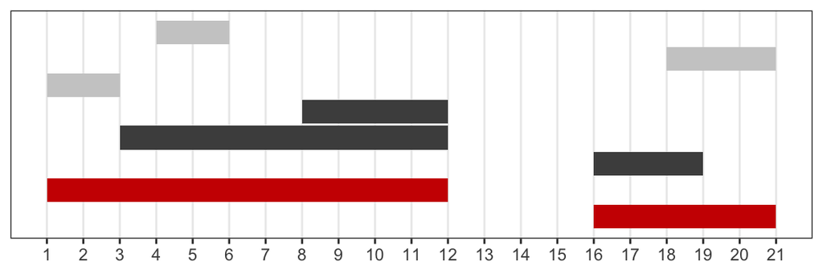

```r
IRangesMethodToTable(IRanges::union, range_1, range_2) %>% plotIRanges(.)
```

**Note**

**Important arguments of `punion(x, y, ...)`**

`punion()` works pair by pair (1st range of x with 1st range of y, 2nd with 2nd, …) and must return **exactly one range per pair**.

- **`fill.gap`** - what to do when the two ranges of a pair do not overlap (there is a gap between them), so their union would be two separate pieces:
  - `FALSE` (default) - error: *“some pair of ranges have a gap within the 2 members of the pair”*
  - `TRUE` - return one range from the smallest start to the largest end, **filling the gap**

Here every pair has a gap (4-6 and 8-12, 18-21 and 3-12, 1-3 and 16-19), so without `fill.gap = TRUE` this code fails. Note that the result also covers positions which are in **neither** range (e.g. 1-19 for the 3rd pair) - the set version `union()` never does that.

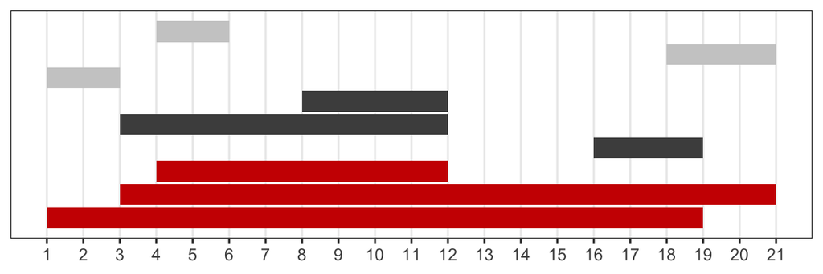

```r
IRangesMethodToTable(punion, range_1, range_2, fill.gap = TRUE) %>% plotIRanges(.)
```

### *intersect()* and *pintersect()*

```r
range_1 <- IRanges(start = c(9, 18, 1), end = c(13, 22, 9))
range_2 <- IRanges(start = c(8, 3, 2), end = c(13, 20, 5))
```

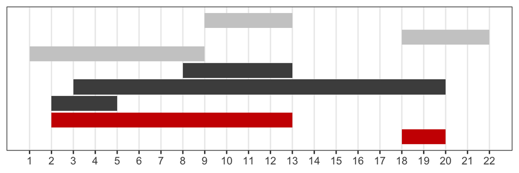

```r
IRangesMethodToTable(IRanges::intersect, range_1, range_2) %>% plotIRanges(.)
```

**Note**

**Important arguments of `pintersect(x, y, ...)`**

Like `punion()`, `pintersect()` works pair by pair and returns exactly one range per pair.

- **`resolve.empty`** - what to do when the two ranges of a pair do not overlap. Their intersection is then an **empty range** (width 0), but an empty range still needs a start position:
  - `"none"` (default) - error: *“some intersections produce ambiguous empty ranges”*
  - `"max.start"` - the empty range starts at the larger of the two starts
  - `"start.x"` - the empty range starts at the start of the range from x

For example `10-15` and `20-25` give an empty range starting at 20 with `"max.start"` and at 10 with `"start.x"`. In our example all three pairs overlap, so `resolve.empty` does not change the result here.

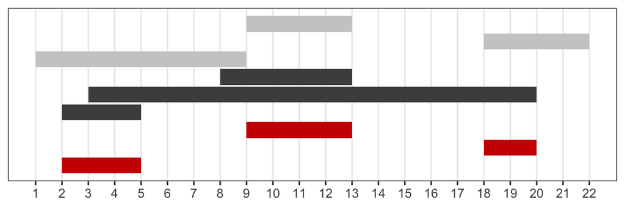

```r
IRangesMethodToTable(pintersect, range_1, range_2, resolve.empty = "max.start") %>% plotIRanges(.)
```

### *setdiff()* and *psetdiff()*

```r
range_1 <- IRanges(start = c(4, 18, 1), end = c(7, 22, 4))
range_2 <- IRanges(start = c(10, 4, 16), end = c(13, 13, 20))
```

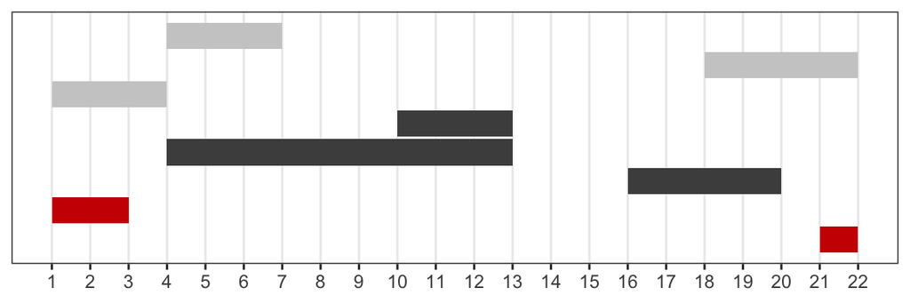

```r
IRangesMethodToTable(IRanges::setdiff, range_1, range_2) %>% plotIRanges(.)
```

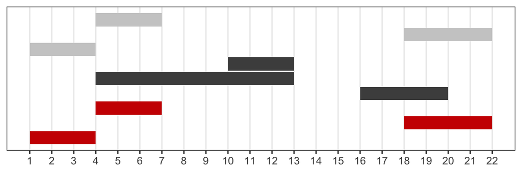

```r
IRangesMethodToTable(psetdiff, range_1, range_2) %>% plotIRanges(.)
```

### *gaps()* and *pgaps()*

`gaps()` accepts only one IRanges object as an argument. It is also one of the inter-range transformations.

```r
range_1 <- IRanges(start = c(4, 18, 1), end = c(7, 22, 4))
range_2 <- IRanges(start = c(10, 3, 16), end = c(13, 13, 20))
```

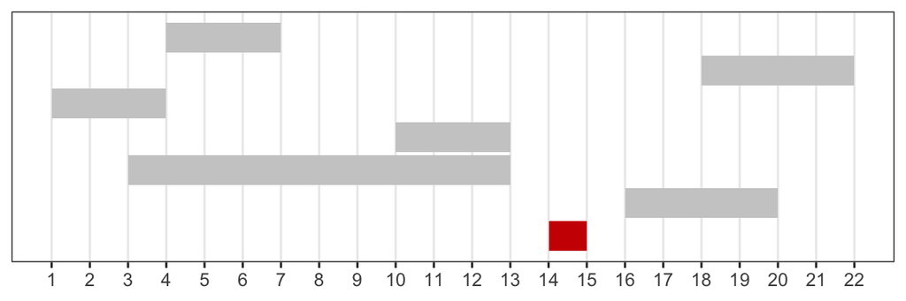

```r
IRangesMethodToTable(gaps, c(range_1, range_2)) %>% plotIRanges(.)
```

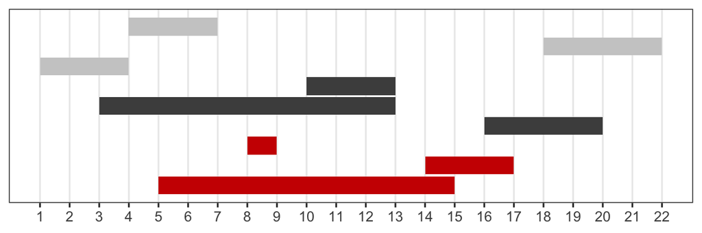

```r
IRangesMethodToTable(pgap, range_1, range_2) %>% plotIRanges(.)
```

## Intra range operations

Intra range methods transform each range individually and independently of other ranges. They return an object parallel to the input object - *i-th* range corresponds to the *i-th* range in the input.

### *shift()*

```r
range_1 <- IRanges(start = c(4, 5, 8, 3, 16),
                   end = c(9, 9, 13, 13, 20))
```

**Note**

**Important arguments of `shift(x, shift)`**

- **`shift`** - by how many positions to move each range. The width stays the same:
  - positive number - move to the **right** (e.g. `shift = 7`: 4-9 becomes 11-16)
  - negative number - move to the **left** (e.g. `shift = -2`: 4-9 becomes 2-7)

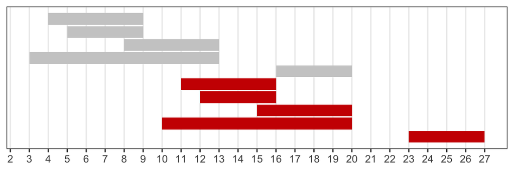

```r
IRangesMethodToTable(shift, range_1, shift = 7) %>% plotIRanges(.)
```

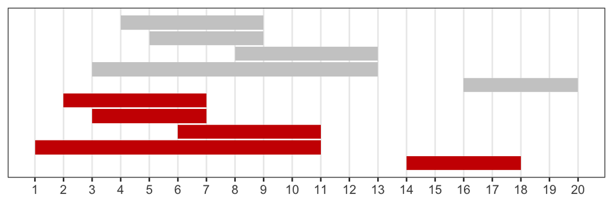

```r
IRangesMethodToTable(shift, range_1, shift = -2) %>% plotIRanges(.)
```

### *narrow()*

Relative start and end positions: start at 3rd and end at 5th position

**Note**

**Important arguments of `narrow(x, start, end, width)`**

- **`start`**, **`end`** - positions **relative to the range itself**, not genome coordinates: `1` is the first position of the range. Here range 4-9 with `start = 3, end = 5` keeps its 3rd to 5th position, i.e. 6-8
- negative values count from the end of the range: `start = -2` keeps the last two positions (8-9)
- **`width`** - can be given instead of one of `start` / `end`

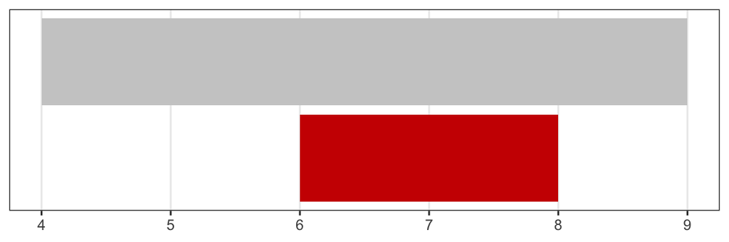

```r
IRangesMethodToTable(narrow, range_1[1], start=3, end=5) %>% plotIRanges(.)
```

### *resize()*

The `width` argument is the **new width** of each range. The `fix` argument determines **which part of each range remains constant** when resizing its width.

- **`fix = "start"`**  
  The **start coordinate** stays fixed.  
  The end position shifts to achieve the new width.  
  (Equivalent to `start = TRUE` logic in other functions.)
- **`fix = "end"`**  
  The **end coordinate** stays fixed.  
  The start position shifts to adjust the width.
- **`fix = "center"`**  
  The **midpoint** of the range stays constant, and the range expands or contracts **symmetrically** on both sides.

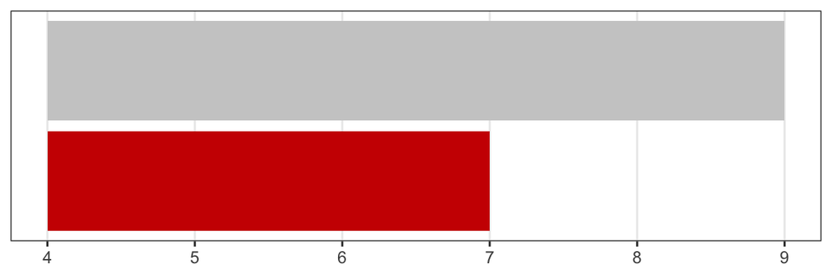

```r
IRangesMethodToTable(resize, range_1[1], width = 4, fix = "start") %>% plotIRanges(.)
```

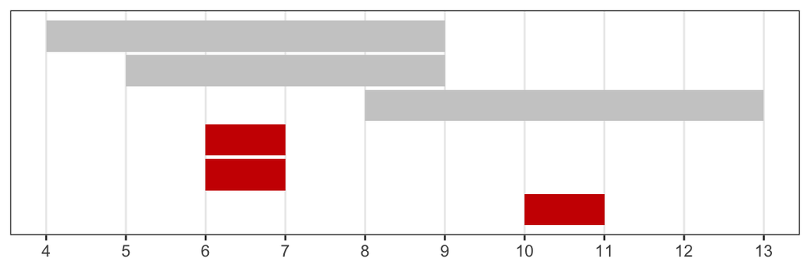

```r
IRangesMethodToTable(resize, range_1[1:3], width = 2, fix = "center") %>% plotIRanges(.)
```

### *flank()*

When using the `flank()` function, several arguments control where the flanking regions are placed:

- **`width`**:  
  The **length** of the flanking region.
- **`start = TRUE`**:  
  The flanking region is generated **relative to the start** of each range.
- **`start = FALSE`**:  
  The flanking region is generated **relative to the end** of each range.
- **`both = TRUE`**:  
  The flanking region extends **to both sides of the reference point** (start or end) — for example, with `width = 2` and `start = TRUE`, the region covers two bases **before the start** and the **first two bases of the range** (range 4-9 gives 2-5).

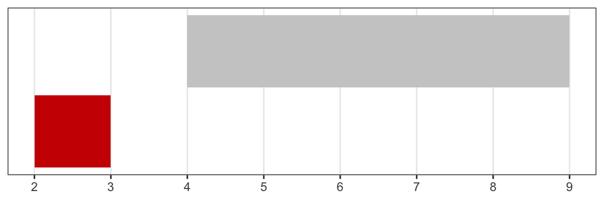

```r
IRangesMethodToTable(flank, range_1[1], width = 2, start = TRUE) %>%  plotIRanges(.)
```

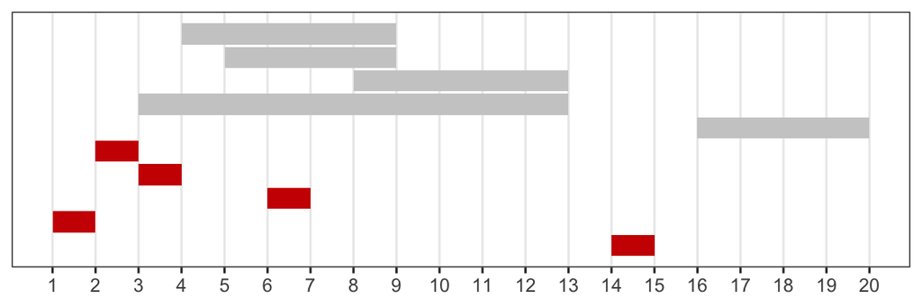

```r
IRangesMethodToTable(flank, range_1, width = 2, start = TRUE) %>%  plotIRanges(.)
```

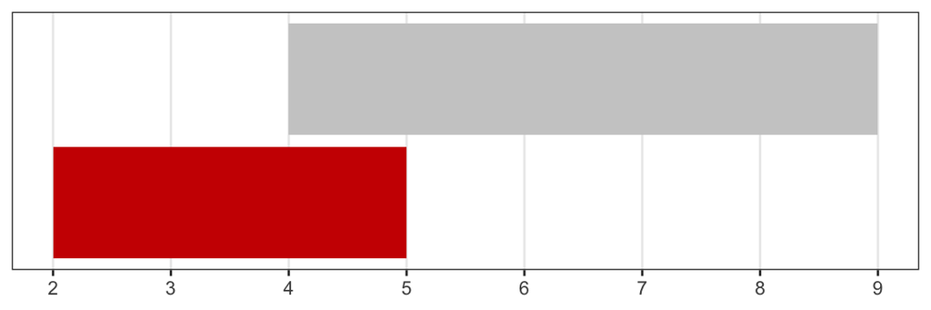

```r
IRangesMethodToTable(flank, range_1[1], width = 2, start = TRUE, both = TRUE) %>% plotIRanges(.)
```

### *promoters()*

Similar to *flank()*, but takes start as reference point.

**Note**

**Important arguments of `promoters(x, upstream, downstream)`**

- **`upstream`** - how many positions **before** the start to include
- **`downstream`** - how many positions **from** the start onward to include (the start itself counts)

Here range 4-9 with `upstream = 3, downstream = 2` gives 1-5: three positions before the start (1-3) and the first two of the range (4-5). On a GRanges object with `strand = "-"` the start is the right end of the range, so upstream is to the right.

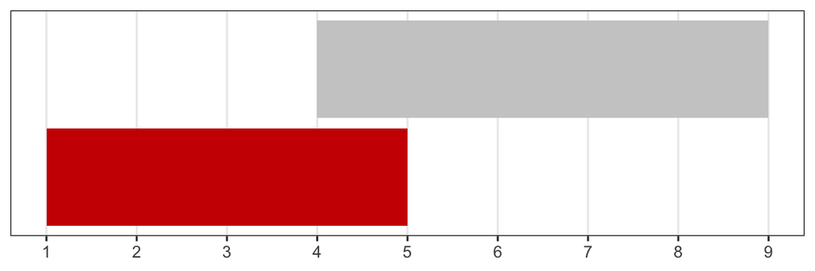

```r
IRangesMethodToTable(promoters, upstream = 3, downstream = 2, range_1[1]) %>% plotIRanges(.)
```

### *reflect()*

Reflects (mirrors) the input range(s) relative to the midpoint of the specified bounds (e.g., (10, 11)), flipping the ranges as though the bounds define the axis of reflection.

**Note**

**Important arguments of `reflect(x, bounds)`**

- **`bounds`** - an IRanges object whose midpoint is the mirror. Here `bounds = 10-11`, so the mirror is at 10.5 and range 4-9 becomes 12-17. If `bounds` has one range it is used for all ranges of x, otherwise it must have one range per range of x

Because `bounds` is itself an IRanges object, our `IRangesMethodToTable()` function treats it as an input range and it is also drawn on the plot.

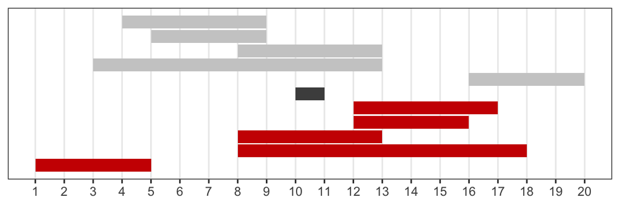

```r
IRangesMethodToTable(reflect, range_1, bounds = IRanges(start = 10, end = 11)) %>% plotIRanges(.)
```

### *restrict()*

The function `restrict()` **trims or limits ranges** to lie within specified boundaries.  
It’s used when you want to **keep only the portions of ranges that fall inside a given interval**.

**Note**

**Important arguments of `restrict(x, start, end, keep.all.ranges)`**

- **`start`**, **`end`** - the boundaries (genome coordinates). Parts of ranges outside 3-9 are cut off, e.g. 8-13 becomes 8-9
- **`keep.all.ranges`** - what to do with ranges that lie **completely outside** the boundaries:
  - `FALSE` (default) - they are dropped (here 16-20 disappears, so the result has 4 ranges instead of 5)
  - `TRUE` - they are kept as empty ranges (width 0)

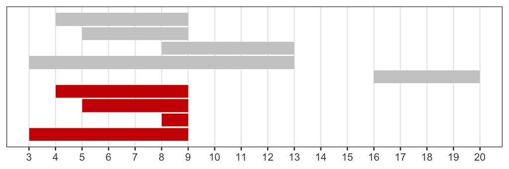

```r
IRangesMethodToTable(restrict, range_1, start = 3, end = 9) %>% plotIRanges(.)
```

## Inter range operations

Inter range methods transform all the ranges as a set to produce a new set of ranges. They return an object that is generally NOT parallel to the input object.

### *range()*

The function `range()` returns **one range from the smallest start to the largest end** of all ranges - the region which covers everything, including the gaps between ranges.  
For example, the whole region spanned by all exons of a gene. Here ranges 3-13 and 16-20 give 3-20 (position 14-15 is in no range, but is included).

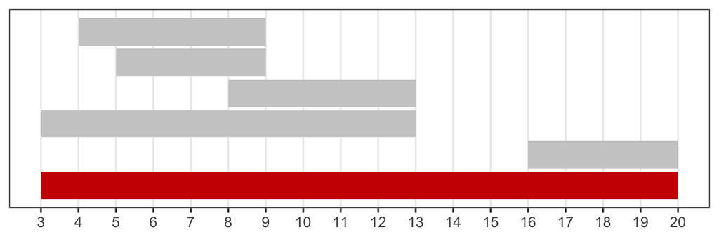

```r
IRangesMethodToTable(range, range_1) %>% plotIRanges(.)
```

### *reduce()*

The function `reduce()` **merges overlapping (and touching) ranges** into one, but **keeps the gaps** between them. The result is the smallest set of non-overlapping ranges which cover exactly the same positions as the input.  
For example, merging overlapping reads or exons of all transcripts of a gene into regions which are covered at least once. Here 4-9, 5-9, 8-13 and 3-13 are merged into 3-13, and 16-20 stays on its own.

**Note**

**Important arguments of `reduce(x, min.gapwidth)`**

- **`min.gapwidth`** - ranges separated by a gap **smaller** than this are merged. Default is `1`, so only overlapping or touching ranges (e.g. 1-3 and 4-6) are merged. With `min.gapwidth = 2`, 1-3 and 5-8 (gap of one position) are also merged into 1-8

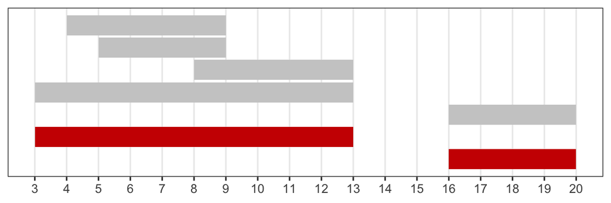

```r
IRangesMethodToTable(reduce, range_1) %>% plotIRanges(.)
```

### *disjoin()*

The function `disjoin()` **cuts the ranges at every start and end**, so that the result consists of non-overlapping pieces, and each position is covered by exactly the same input ranges within a piece.  
For example, splitting exons of different transcripts into parts which are shared by all transcripts and parts which are unique to some of them. Here 4-9 and 8-13 give three pieces: 4-7 (only in the 1st range), 8-9 (in both) and 10-13 (only in the 2nd range).

**Tip**

Compare the three methods on the same ranges: `range()` gives **1** range (gaps filled), `reduce()` gives as **few** ranges as possible (gaps kept), `disjoin()` gives as **many** pieces as needed so that no two pieces overlap.

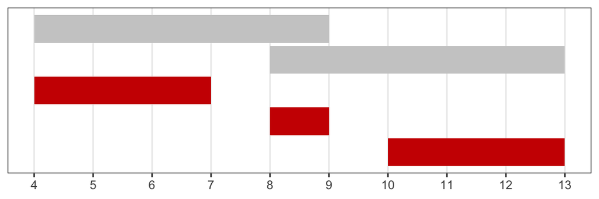

```r
IRangesMethodToTable(disjoin, range_1[c(1,3)]) %>% plotIRanges(.)
```

## Interval overlaps

There are several methods for finding and counting interval overlaps between two IRanges object - query and a subject.

### *findOverlaps()*

```r
(overlaps <- findOverlaps(range_1, range_2))
```

```
Hits object with 7 hits and 0 metadata columns:
      queryHits subjectHits
      <integer>   <integer>
  [1]         1           2
  [2]         2           2
  [3]         3           2
  [4]         3           1
  [5]         4           2
  [6]         4           1
  [7]         5           3
  -------
  queryLength: 5 / subjectLength: 3
```

Extracting overlapping ranges from result is done with `queryHits()` and `subjectHits()`.

```r
(query_ranges <- range_1[queryHits(overlaps)])
```

```
IRanges object with 7 ranges and 0 metadata columns:
          start       end     width
      <integer> <integer> <integer>
  [1]         4         9         6
  [2]         5         9         5
  [3]         8        13         6
  [4]         8        13         6
  [5]         3        13        11
  [6]         3        13        11
  [7]        16        20         5
```

```r
(subject_ranges <- range_2[subjectHits(overlaps)])
```

```
IRanges object with 7 ranges and 0 metadata columns:
          start       end     width
      <integer> <integer> <integer>
  [1]         3        13        11
  [2]         3        13        11
  [3]         3        13        11
  [4]        10        13         4
  [5]         3        13        11
  [6]        10        13         4
  [7]        16        20         5
```

### *countOverlaps()*

```r
countOverlaps(range_1, range_2)
```

```
[1] 1 1 2 2 1
```

```r
countOverlaps(range_2, range_1)
```

```
[1] 2 4 1
```

### *subsetByOverlaps()*

The function `subsetByOverlaps()` returns **only the ranges from one set that overlap another set**.

```r
subsetByOverlaps(range_1, range_2)
```

```
IRanges object with 5 ranges and 0 metadata columns:
          start       end     width
      <integer> <integer> <integer>
  [1]         4         9         6
  [2]         5         9         5
  [3]         8        13         6
  [4]         3        13        11
  [5]        16        20         5
```

## GenomicRanges methods overview

**Important**

GenomicRanges = IRanges + genomic info. Used to describe:

- annotations, e.g., exons, genes, binding sites, …
- data, e.g., aligned reads, called peaks, copy number regions

For example:

```r
(grange_1 <- GRanges("chr1", range_1, strand = "+"))
```

```
GRanges object with 5 ranges and 0 metadata columns:
      seqnames    ranges strand
         <Rle> <IRanges>  <Rle>
  [1]     chr1       4-9      +
  [2]     chr1       5-9      +
  [3]     chr1      8-13      +
  [4]     chr1      3-13      +
  [5]     chr1     16-20      +
  -------
  seqinfo: 1 sequence from an unspecified genome; no seqlengths
```

```r
(grange_2 <- GRanges("chr2", range_2, strand = "-"))
```

```
GRanges object with 3 ranges and 0 metadata columns:
      seqnames    ranges strand
         <Rle> <IRanges>  <Rle>
  [1]     chr2     10-13      -
  [2]     chr2      3-13      -
  [3]     chr2     16-20      -
  -------
  seqinfo: 1 sequence from an unspecified genome; no seqlengths
```

**Important**

`seqnames` vs `seqlevels` in GenomicRanges

When working with genomic ranges (`GRanges` objects), each range is associated with a **sequence name** — typically a chromosome or contig.  
Two related functions, `seqnames()` and `seqlevels()`, are used to access this information, but they serve different purposes.

`seqnames()` - Returns the **sequence name (chromosome)** for **each individual range**.  
- The output is a vector with one entry per range.

`seqlevels()` - Returns the **set of unique sequence** names (chromosomes) present or allowed in the object. - This defines the **reference genome structure** — even if some levels currently have no ranges.

Few additional functions to access new data:

```r
seqnames(grange_1) # chromosomes, but can also be contigs, scaffolds etc.
```

```
factor-Rle of length 5 with 1 run
  Lengths:    5
  Values : chr1
Levels(1): chr1
```

```r
seqlevels(grange_1)
```

```
[1] "chr1"
```

```r
strand(grange_1)
```

```
factor-Rle of length 5 with 1 run
  Lengths: 5
  Values : +
Levels(3): + - *
```

```r
ranges(grange_1)
```

```
IRanges object with 5 ranges and 0 metadata columns:
          start       end     width
      <integer> <integer> <integer>
  [1]         4         9         6
  [2]         5         9         5
  [3]         8        13         6
  [4]         3        13        11
  [5]        16        20         5
```

Adding additional metadata:

```r
mcols(grange_1)$exon_id <- 1:length(grange_1)
mcols(grange_2)$exon_id <- length(grange_2):1
mcols(grange_1)$transcript_id <- "tx_1"
mcols(grange_2)$transcript_id <- "tx_2"
grange_1
```

```
GRanges object with 5 ranges and 2 metadata columns:
      seqnames    ranges strand |   exon_id transcript_id
         <Rle> <IRanges>  <Rle> | <integer>   <character>
  [1]     chr1       4-9      + |         1          tx_1
  [2]     chr1       5-9      + |         2          tx_1
  [3]     chr1      8-13      + |         3          tx_1
  [4]     chr1      3-13      + |         4          tx_1
  [5]     chr1     16-20      + |         5          tx_1
  -------
  seqinfo: 1 sequence from an unspecified genome; no seqlengths
```

```r
mcols(grange_2)
```

```
DataFrame with 3 rows and 2 columns
    exon_id transcript_id
  <integer>   <character>
1         3          tx_2
2         2          tx_2
3         1          tx_2
```

## *GRanges* methods overview

All methods which work on *IRanges* objects also work on *GRanges*, with some limitations and/or additional arguments. For example:

```r
grange_1
```

```
GRanges object with 5 ranges and 2 metadata columns:
      seqnames    ranges strand |   exon_id transcript_id
         <Rle> <IRanges>  <Rle> | <integer>   <character>
  [1]     chr1       4-9      + |         1          tx_1
  [2]     chr1       5-9      + |         2          tx_1
  [3]     chr1      8-13      + |         3          tx_1
  [4]     chr1      3-13      + |         4          tx_1
  [5]     chr1     16-20      + |         5          tx_1
  -------
  seqinfo: 1 sequence from an unspecified genome; no seqlengths
```

```r
grange_2
```

```
GRanges object with 3 ranges and 2 metadata columns:
      seqnames    ranges strand |   exon_id transcript_id
         <Rle> <IRanges>  <Rle> | <integer>   <character>
  [1]     chr2     10-13      - |         3          tx_2
  [2]     chr2      3-13      - |         2          tx_2
  [3]     chr2     16-20      - |         1          tx_2
  -------
  seqinfo: 1 sequence from an unspecified genome; no seqlengths
```

```r
(overlaps <- findOverlaps(grange_1, grange_2))
```

```
Hits object with 0 hits and 0 metadata columns:
   queryHits subjectHits
   <integer>   <integer>
  -------
  queryLength: 5 / subjectLength: 3
```

Why are there no overlaps? Seqnames/seqlevels are different!

```r
seqlevels(grange_2) <- "chr1"
grange_1
```

```
GRanges object with 5 ranges and 2 metadata columns:
      seqnames    ranges strand |   exon_id transcript_id
         <Rle> <IRanges>  <Rle> | <integer>   <character>
  [1]     chr1       4-9      + |         1          tx_1
  [2]     chr1       5-9      + |         2          tx_1
  [3]     chr1      8-13      + |         3          tx_1
  [4]     chr1      3-13      + |         4          tx_1
  [5]     chr1     16-20      + |         5          tx_1
  -------
  seqinfo: 1 sequence from an unspecified genome; no seqlengths
```

```r
grange_2
```

```
GRanges object with 3 ranges and 2 metadata columns:
      seqnames    ranges strand |   exon_id transcript_id
         <Rle> <IRanges>  <Rle> | <integer>   <character>
  [1]     chr1     10-13      - |         3          tx_2
  [2]     chr1      3-13      - |         2          tx_2
  [3]     chr1     16-20      - |         1          tx_2
  -------
  seqinfo: 1 sequence from an unspecified genome; no seqlengths
```

```r
(overlaps <- findOverlaps(grange_1, grange_2))
```

```
Hits object with 0 hits and 0 metadata columns:
   queryHits subjectHits
   <integer>   <integer>
  -------
  queryLength: 5 / subjectLength: 3
```

Why are there still no overlaps? Strands are different!

**Note**

**`ignore.strand`** - GRanges methods by default compare only ranges on the **same strand** (`"*"` matches both `"+"` and `"-"`).

- `FALSE` (default) - ranges on `"+"` and `"-"` never overlap
- `TRUE` - strand is ignored and only the positions are compared. Methods that return new ranges, like `intersect()`, then return them with strand `"*"`

```r
(overlaps <- findOverlaps(grange_1, grange_2, ignore.strand = T))
```

```
Hits object with 7 hits and 0 metadata columns:
      queryHits subjectHits
      <integer>   <integer>
  [1]         1           2
  [2]         2           2
  [3]         3           2
  [4]         3           1
  [5]         4           2
  [6]         4           1
  [7]         5           3
  -------
  queryLength: 5 / subjectLength: 3
```

Another example:

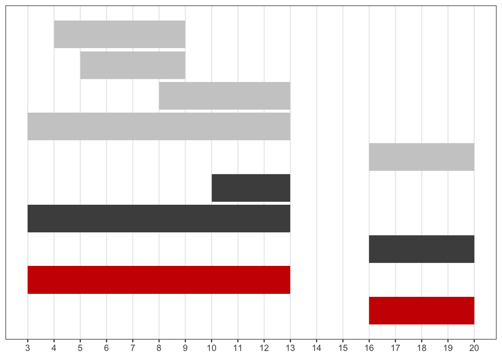

```r
IRangesMethodToTable(GenomicRanges::intersect, grange_1, grange_2, ignore.strand = T) %>% plotIRanges(.)
```

Input data to *GRanges* from table:

```r
ranges_tb <- data.table::data.table(chromosomes = paste("chr", sample(1:10, 5)),
                     gene_start = c(1, 8, 5, 3, 2),
                     gene_end = c(12, 13, 15, 8, 6),
                     gene_strand = sample(c("+", "-"), 5, replace = T),
                     gene_id = paste0("gene_", sample(1:10, 5)),
                     score = sample(1:100, 5))
 print(ranges_tb)
```

```
   chromosomes gene_start gene_end gene_strand gene_id score
        <char>      <num>    <num>      <char>  <char> <int>
1:       chr 2          1       12           +  gene_2    74
2:       chr 8          8       13           +  gene_5    84
3:       chr 6          5       15           -  gene_1    32
4:       chr 9          3        8           +  gene_6    24
5:       chr 4          2        6           -  gene_3    93
```

```r
makeGRangesFromDataFrame(df = ranges_tb,
                         seqnames.field = "chromosomes",
                         start.field = "gene_start",
                         end.field = "gene_end",
                         strand.field = "gene_strand",
                         keep.extra.columns = TRUE)
```

```
GRanges object with 5 ranges and 2 metadata columns:
      seqnames    ranges strand |     gene_id     score
         <Rle> <IRanges>  <Rle> | <character> <integer>
  [1]    chr 2      1-12      + |      gene_2        74
  [2]    chr 8      8-13      + |      gene_5        84
  [3]    chr 6      5-15      - |      gene_1        32
  [4]    chr 9       3-8      + |      gene_6        24
  [5]    chr 4       2-6      - |      gene_3        93
  -------
  seqinfo: 5 sequences from an unspecified genome; no seqlengths
```

If your column names are correct you can directly call `GRanges()` on data.frame/tibble/data.table:

```r
(ranges_tb <- GRanges(data.table::data.table(seqnames = paste("chr", sample(1:10, 5)),
                             start = c(1, 8, 5, 3, 2),
                             end = c(12, 13, 15, 8, 6),
                             strand = sample(c("+", "-"), 5, replace = T),
                             gene_id = paste0("gene_", sample(1:10, 5)),
                             score = sample(1:100, 5))))
```

```
GRanges object with 5 ranges and 2 metadata columns:
      seqnames    ranges strand |     gene_id     score
         <Rle> <IRanges>  <Rle> | <character> <integer>
  [1]    chr 5      1-12      - |      gene_4        18
  [2]    chr 6      8-13      + |      gene_2        62
  [3]    chr 2      5-15      - |      gene_7        83
  [4]    chr 8       3-8      + |      gene_8        97
  [5]    chr 4       2-6      - |     gene_10        38
  -------
  seqinfo: 5 sequences from an unspecified genome; no seqlengths
```

## *GRangesList* methods overview

Used when you want to store exons in transcripts or aligned reads with gaps/paired-end reads.

```r
grange_1_2 <- c(grange_1, grange_2)
(grange_list <- split(grange_1_2, mcols(grange_1_2)$transcript_id))
```

```
GRangesList object of length 2:
$tx_1
GRanges object with 5 ranges and 2 metadata columns:
      seqnames    ranges strand |   exon_id transcript_id
         <Rle> <IRanges>  <Rle> | <integer>   <character>
  [1]     chr1       4-9      + |         1          tx_1
  [2]     chr1       5-9      + |         2          tx_1
  [3]     chr1      8-13      + |         3          tx_1
  [4]     chr1      3-13      + |         4          tx_1
  [5]     chr1     16-20      + |         5          tx_1
  -------
  seqinfo: 1 sequence from an unspecified genome; no seqlengths

$tx_2
GRanges object with 3 ranges and 2 metadata columns:
      seqnames    ranges strand |   exon_id transcript_id
         <Rle> <IRanges>  <Rle> | <integer>   <character>
  [1]     chr1     10-13      - |         3          tx_2
  [2]     chr1      3-13      - |         2          tx_2
  [3]     chr1     16-20      - |         1          tx_2
  -------
  seqinfo: 1 sequence from an unspecified genome; no seqlengths
```

Subset:

```r
grange_list[[1]]
```

```
GRanges object with 5 ranges and 2 metadata columns:
      seqnames    ranges strand |   exon_id transcript_id
         <Rle> <IRanges>  <Rle> | <integer>   <character>
  [1]     chr1       4-9      + |         1          tx_1
  [2]     chr1       5-9      + |         2          tx_1
  [3]     chr1      8-13      + |         3          tx_1
  [4]     chr1      3-13      + |         4          tx_1
  [5]     chr1     16-20      + |         5          tx_1
  -------
  seqinfo: 1 sequence from an unspecified genome; no seqlengths
```

```r
# also works: grange_list$"tx_1"
```

Accessors and interval operations from *GRanges* also work on *GRangesList*, but usually return a list. For example:

```r
seqnames(grange_list)
```

```
RleList of length 2
$tx_1
factor-Rle of length 5 with 1 run
  Lengths:    5
  Values : chr1
Levels(1): chr1

$tx_2
factor-Rle of length 3 with 1 run
  Lengths:    3
  Values : chr1
Levels(1): chr1
```

```r
ranges(grange_list)
```

```
IRangesList object of length 2:
$tx_1
IRanges object with 5 ranges and 0 metadata columns:
          start       end     width
      <integer> <integer> <integer>
  [1]         4         9         6
  [2]         5         9         5
  [3]         8        13         6
  [4]         3        13        11
  [5]        16        20         5

$tx_2
IRanges object with 3 ranges and 0 metadata columns:
          start       end     width
      <integer> <integer> <integer>
  [1]        10        13         4
  [2]         3        13        11
  [3]        16        20         5
```

```r
strand(grange_list)
```

```
RleList of length 2
$tx_1
factor-Rle of length 5 with 1 run
  Lengths: 5
  Values : +
Levels(3): + - *

$tx_2
factor-Rle of length 3 with 1 run
  Lengths: 3
  Values : -
Levels(3): + - *
```

```r
start(grange_list)
```

```
IntegerList of length 2
[["tx_1"]] 4 5 8 3 16
[["tx_2"]] 10 3 16
```

```r
# and so on ...
```

You can also use mathematical and other operations on them:

```r
sum(width(grange_list))
```

```
tx_1 tx_2
  33   20
```

Most of the *intra*-, *inter*- and *between*-range methods also operate on *GRangesList* objects:

```r
shift(grange_list, 20)
```

```
GRangesList object of length 2:
$tx_1
GRanges object with 5 ranges and 2 metadata columns:
      seqnames    ranges strand |   exon_id transcript_id
         <Rle> <IRanges>  <Rle> | <integer>   <character>
  [1]     chr1     24-29      + |         1          tx_1
  [2]     chr1     25-29      + |         2          tx_1
  [3]     chr1     28-33      + |         3          tx_1
  [4]     chr1     23-33      + |         4          tx_1
  [5]     chr1     36-40      + |         5          tx_1
  -------
  seqinfo: 1 sequence from an unspecified genome; no seqlengths

$tx_2
GRanges object with 3 ranges and 2 metadata columns:
      seqnames    ranges strand |   exon_id transcript_id
         <Rle> <IRanges>  <Rle> | <integer>   <character>
  [1]     chr1     30-33      - |         3          tx_2
  [2]     chr1     23-33      - |         2          tx_2
  [3]     chr1     36-40      - |         1          tx_2
  -------
  seqinfo: 1 sequence from an unspecified genome; no seqlengths
```

*GRangesList* to *GRanges*:

```r
unlist(grange_list)
```

```
GRanges object with 8 ranges and 2 metadata columns:
       seqnames    ranges strand |   exon_id transcript_id
          <Rle> <IRanges>  <Rle> | <integer>   <character>
  tx_1     chr1       4-9      + |         1          tx_1
  tx_1     chr1       5-9      + |         2          tx_1
  tx_1     chr1      8-13      + |         3          tx_1
  tx_1     chr1      3-13      + |         4          tx_1
  tx_1     chr1     16-20      + |         5          tx_1
  tx_2     chr1     10-13      - |         3          tx_2
  tx_2     chr1      3-13      - |         2          tx_2
  tx_2     chr1     16-20      - |         1          tx_2
  -------
  seqinfo: 1 sequence from an unspecified genome; no seqlengths
```

Loops - `lapply()`, `sapply()`, `mapply()`, `endoapply()`, `mendoapply()`, `Map()` and `Reduce()`:

```r
lapply(grange_list, length)
```

```
$tx_1
[1] 5

$tx_2
[1] 3
```

```r
sapply(grange_list, length)
```

```
tx_1 tx_2
   5    3
```

`endoapply()` transforms an object to another instance of the same class:

```r
endoapply(grange_list, rev)
```

```
GRangesList object of length 2:
$tx_1
GRanges object with 5 ranges and 2 metadata columns:
      seqnames    ranges strand |   exon_id transcript_id
         <Rle> <IRanges>  <Rle> | <integer>   <character>
  [1]     chr1     16-20      + |         5          tx_1
  [2]     chr1      3-13      + |         4          tx_1
  [3]     chr1      8-13      + |         3          tx_1
  [4]     chr1       5-9      + |         2          tx_1
  [5]     chr1       4-9      + |         1          tx_1
  -------
  seqinfo: 1 sequence from an unspecified genome; no seqlengths

$tx_2
GRanges object with 3 ranges and 2 metadata columns:
      seqnames    ranges strand |   exon_id transcript_id
         <Rle> <IRanges>  <Rle> | <integer>   <character>
  [1]     chr1     16-20      - |         1          tx_2
  [2]     chr1      3-13      - |         2          tx_2
  [3]     chr1     10-13      - |         3          tx_2
  -------
  seqinfo: 1 sequence from an unspecified genome; no seqlengths
```

Overlap *GRangesList* with *GRanges*:

```r
findOverlaps(c(grange_1, grange_2), grange_list)
```

```
Hits object with 8 hits and 0 metadata columns:
      queryHits subjectHits
      <integer>   <integer>
  [1]         1           1
  [2]         2           1
  [3]         3           1
  [4]         4           1
  [5]         5           1
  [6]         6           2
  [7]         7           2
  [8]         8           2
  -------
  queryLength: 8 / subjectLength: 2
```

## Additional resources

### Cheat sheets

*Bioconductor* cheatsheet: https://rpubs.com/Pazz/bioc_cheat_sheet

*Bioconductor* for Genomic Data Science: http://kasperdanielhansen.github.io/genbioconductor/

### Some other useful packages to have in mind:

*GenomicFeatures* - import and query gene models

*GenomicAlignments* - representation and manipulation of short genomic alignments

*rtracklayer* - R interface to genome annotation files and the UCSC genome browser

*BSgenome* - efficient representation of full genomes and their SNPs

*ggbio* - visualization tools for genomic data

### Biological terminology

#### Gene structure

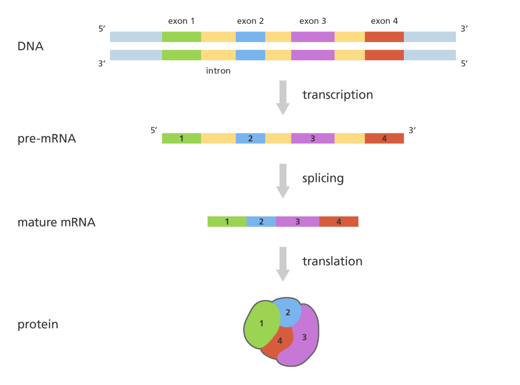

Upstream/downstream vs. sense/antisense vs. plus/minus strand